# EDA v1

Marcus Needham

2024-09-18

# Introduction

This report provides an exploratory data analysis (EDA) of Swire Coca-Cola’s machine breakdown and downtime data, with a focus on identifying key variables for building a predictive maintenance model. The analysis covers the exploration of machine conditions, parts involved in breakdowns, downtime durations, and trends over time.

# Libraries and Data Loading

```r
# Load the dataset
iwc_data <- read.csv("IWC_Work_Orders_Extract.csv")

# View the structure of the dataset
str(iwc_data)
```

```
## 'data.frame':    1427264 obs. of  25 variables:
##  $ ORDER_ID                       : num  7.06e+08 7.04e+08 7.04e+08 7.04e+08 7.05e+08 ...
##  $ PLANT_ID                       : chr  "G812" "G812" "G812" "G812" ...
##  $ PRODUCTION_LOCATION            : chr  "ROMA" "ROMA" "ROMA" "ROMA" ...
##  $ EXECUTION_START_DATE           : chr  "2024-05-04" "2022-09-13" "2022-12-21" "2022-07-04" ...
##  $ EXECUTION_FINISH_DATE          : chr  "2024-05-12" "2022-09-13" "2022-12-21" "2022-07-04" ...
##  $ ACTUAL_START_TIME              : chr  "06:00:00.000" "06:00:00.000" "07:00:00.000" "06:00:00.000" ...
##  $ ACTUAL_FINISH_TIME             : chr  "23:04:08.000" "17:17:24.000" "07:00:00.000" "06:00:00.000" ...
##  $ ACTUAL_WORK_IN_MINUTES         : num  390 420 30 60 120 18 480 30 30 30 ...
##  $ MAINTENANCE_PLAN               : chr  "" "" "" "" ...
##  $ MAINTENANCE_ITEM               : int  NA NA NA NA NA 40534 NA NA NA NA ...
##  $ MAINTENANCE_ACTIVITY_TYPE      : chr  "Unplanned" "Unplanned" "Unplanned" "Unplanned" ...
##  $ ORDER_DESCRIPTION              : chr  "L2 GEARBOX LEAK (SEE ATTACHED)" "LINE 3 CONVEYOR AT CAN CODER" "BROKEN CONVEYOR RAIL" "LINE 3 CONVEYOR" ...
##  $ MAINTENANCE_TYPE_DESCRIPTION   : chr  "Corrective Maintenance Order" "Corrective Maintenance Order" "Corrective Maintenance Order" "Corrective Maintenance Order" ...
##  $ FUNCTIONAL_LOC                 : chr  "G812-PRD-L15-L03-L030-020" "G812-PRD-L15-L03-L030-020" "G812-PRD-L15-L03-L030-020" "G812-PRD-L15-L03-L030-020" ...
##  $ FUNCTIONAL_AREA_NODE_1_MODIFIED: chr  "PRODUCTION" "PRODUCTION" "PRODUCTION" "PRODUCTION" ...
##  $ FUNCTIONAL_AREA_NODE_2_MODIFIED: chr  "G812 PRD FILLER_ROTARY_CAN" "G812 PRD FILLER_ROTARY_CAN" "G812 PRD FILLER_ROTARY_CAN" "G812 PRD FILLER_ROTARY_CAN" ...
##  $ FUNCTIONAL_AREA_NODE_3_MODIFIED: chr  "G812 PRD FILLER_ROTARY_CAN LINE 3" "G812 PRD FILLER_ROTARY_CAN LINE 3" "G812 PRD FILLER_ROTARY_CAN LINE 3" "G812 PRD FILLER_ROTARY_CAN LINE 3" ...
##  $ FUNCTIONAL_AREA_NODE_4_MODIFIED: chr  "CONVEYOR" "CONVEYOR" "CONVEYOR" "CONVEYOR" ...
##  $ FUNCTIONAL_AREA_NODE_5_MODIFIED: chr  "FULL CAN CONVEYOR" "FULL CAN CONVEYOR" "FULL CAN CONVEYOR" "FULL CAN CONVEYOR" ...
##  $ EQUIPMENT_ID                   : int  300126812 300126812 300126812 300126812 300001088 300001088 300001088 300001033 300001033 300001033 ...
##  $ EQUIPMENT_DESC                 : chr  "FULL CAN CONVEYOR (FC41B)" "FULL CAN CONVEYOR (FC41B)" "FULL CAN CONVEYOR (FC41B)" "FULL CAN CONVEYOR (FC41B)" ...
##  $ EQUIP_CAT_DESC                 : chr  "Machines" "Machines" "Machines" "Machines" ...
##  $ EQUIP_START_UP_DATE            : chr  "2020-04-22" "2020-04-22" "2020-04-22" "2020-04-22" ...
##  $ EQUIP_VALID_FROM               : chr  "2020-02-10" "2020-02-10" "2020-02-10" "2020-02-10" ...
##  $ EQUIP_VALID_TO                 : chr  "9999-12-31" "9999-12-31" "9999-12-31" "9999-12-31" ...
```

```r
head(iwc_data)
```

```
##    ORDER_ID PLANT_ID PRODUCTION_LOCATION EXECUTION_START_DATE
## 1 705642457     G812                ROMA           2024-05-04
## 2 704191697     G812                ROMA           2022-09-13
## 3 704466547     G812                ROMA           2022-12-21
## 4 703834477     G812                ROMA           2022-07-04
## 5 704661125     G291               MONZA           2023-03-15
## 6 704948720     G291               MONZA           2023-09-08
##   EXECUTION_FINISH_DATE ACTUAL_START_TIME ACTUAL_FINISH_TIME
## 1            2024-05-12      06:00:00.000       23:04:08.000
## 2            2022-09-13      06:00:00.000       17:17:24.000
## 3            2022-12-21      07:00:00.000       07:00:00.000
## 4            2022-07-04      06:00:00.000       06:00:00.000
## 5            2023-03-15      07:00:00.000       07:00:00.000
## 6            2023-09-08      07:00:00.000       07:00:00.000
##   ACTUAL_WORK_IN_MINUTES MAINTENANCE_PLAN MAINTENANCE_ITEM
```

[output cut: 48 more lines]

```r
summary(iwc_data$ACTUAL_WORK_IN_MINUTES)
```

```
##     Min.  1st Qu.   Median     Mean  3rd Qu.     Max.
##      0.0     12.0     48.0     88.6     90.0 330184.8
```

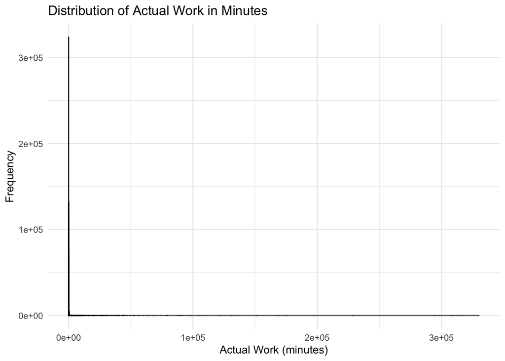

```r
# Remove rows with missing values in ACTUAL_WORK_IN_MINUTES
iwc_data_clean <- iwc_data %>%
  filter(!is.na(ACTUAL_WORK_IN_MINUTES))

# Plot the distribution after cleaning data
ggplot(iwc_data_clean, aes(x = ACTUAL_WORK_IN_MINUTES)) +
  geom_histogram(binwidth = 10, fill = "steelblue", color = "black", alpha = 0.7) +
  labs(title = "Distribution of Actual Work in Minutes",
       x = "Actual Work (minutes)",
       y = "Frequency") +
  theme_minimal()
```

This plot shows the overall distribution of actual work times. Most maintenance events fall within a lower range of time, with few outliers at higher durations.

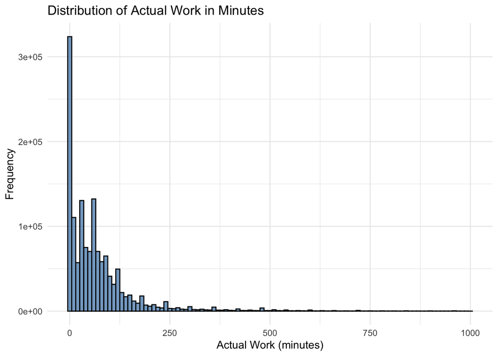

```r
# Remove extreme outliers for better visualization (e.g., work longer than 1000 minutes)
iwc_data_filtered <- iwc_data_clean %>%
  filter(ACTUAL_WORK_IN_MINUTES <= 1000)  # Adjust threshold based on data distribution

# Plot after filtering outliers
ggplot(iwc_data_filtered, aes(x = ACTUAL_WORK_IN_MINUTES)) +
  geom_histogram(binwidth = 10, fill = "steelblue", color = "black", alpha = 0.7) +
  labs(title = "Distribution of Actual Work in Minutes",
       x = "Actual Work (minutes)",
       y = "Frequency") +
  theme_minimal()
```

Here is the distribution of Actual Work time in minutes. You can see that most of the work on maintenance is below 200 minutes.

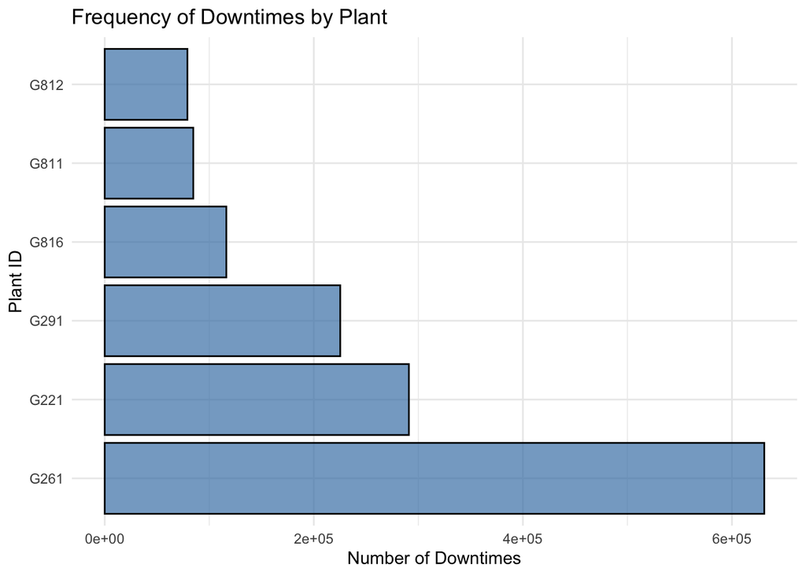

```r
# Group by PLANT_ID and count the number of downtimes per plant
plant_downtime_counts <- iwc_data %>%
  group_by(PLANT_ID) %>%
  summarise(downtime_count = n())

# Plot the downtime frequency per plant
ggplot(plant_downtime_counts, aes(x = reorder(PLANT_ID, -downtime_count), y = downtime_count)) +
  geom_bar(stat = "identity", fill = "steelblue", color = "black", alpha = 0.7) +
  labs(title = "Frequency of Downtimes by Plant",
       x = "Plant ID",
       y = "Number of Downtimes") +
  theme_minimal() +
  coord_flip()  # Flip the coordinates if the plant names are too long
```

This bar chart identifies which plants experience the highest frequency of downtime, highlighting potential areas for operational improvement.

### Looking at common causes of downtime

```r
# Group by maintenance description and count occurrences
common_causes <- iwc_data %>%
  group_by(ORDER_DESCRIPTION, MAINTENANCE_TYPE_DESCRIPTION) %>%
  summarise(count = n()) %>%
  arrange(desc(count))
# View the top 10 most common causes (all are over 1000)
head(common_causes, 12)
```

```
## # A tibble: 12 × 3
## # Groups:   ORDER_DESCRIPTION [12]
##    ORDER_DESCRIPTION                          MAINTENANCE_TYPE_DESCRIPT…¹  count
##    <chr>                                      <chr>                        <int>
##  1 ""                                         ""                          1.14e6
##  2 "DTRINE"                                   "Preventive Maintenance Or… 2.01e3
##  3 "FILTEC, CL3 FOR LUB WHILE OPERATING"      "Preventive Maintenance Or… 1.39e3
##  4 "BEARING_LUBRICATION_PM"                   "Preventive Maintenance Or… 1.31e3
##  5 "E-STOP FOR ELEC MONTHLY SHUTDOWN"         "Preventive Maintenance Or… 1.27e3
##  6 "FILL HEIGHT MONITOR CL4 FOR LUB WHILE OP" "Preventive Maintenance Or… 1.07e3
##  7 "CAPPER DAILY"                             "Preventive Maintenance Or… 1.07e3
##  8 "BOTWMR"                                   "Preventive Maintenance Or… 1.06e3
##  9 "DCANWMR"                                  "Preventive Maintenance Or… 1.06e3
## 10 "DAILY CO2 TANK INSPECTION"                "Preventive Maintenance Or… 1.06e3
## 11 "SWEEP SHOP FLOOR"                         "Preventive Maintenance Or… 1.05e3
## 12 "DRIVERWD"                                 "Preventive Maintenance Or… 1.00e3
## # ℹ abbreviated name: ¹MAINTENANCE_TYPE_DESCRIPTION
```

This the most common causes of maintenance. DTRINE is the highest with over 2,000 cases but the rest are all above 1,000 cases.

```r
common_maintenance_types <- iwc_data %>%
  group_by(MAINTENANCE_TYPE_DESCRIPTION) %>%
  summarise(count = n()) %>%
  arrange(desc(count))

# View the most common maintenance types
print(common_maintenance_types)
```

```
## # A tibble: 6 × 2
##   MAINTENANCE_TYPE_DESCRIPTION     count
##   <chr>                            <int>
## 1 ""                             1135469
## 2 "Preventive Maintenance Order"  151533
## 3 "Corrective Maintenance Order"  134074
## 4 "Administrative Order"            6161
## 5 "Capital Order"                     22
## 6 "Breakdown Maintenance Order"        5
```

```r
# Count unplanned vs. planned downtimes
planned_vs_unplanned <- iwc_data %>%
  group_by(MAINTENANCE_ACTIVITY_TYPE) %>%
  summarise(count = n()) %>%
  mutate(percentage = count / sum(count) * 100) %>%
  arrange(desc(count))

# View the breakdown of unplanned vs. planned
print(planned_vs_unplanned)
```

```
## # A tibble: 2 × 3
##   MAINTENANCE_ACTIVITY_TYPE   count percentage
##   <chr>                       <int>      <dbl>
## 1 Unplanned                 1276877       89.5
## 2 Planned                    150387       10.5
```

Unplanned maintenance happens almost 90% of the time over planned maintenance.

### Time to resolve downtimes

```r
# Calculate mean and median of downtime per location
avg_downtime_by_location <- iwc_data %>%
  group_by(PLANT_ID) %>%
  summarize(
    mean_downtime = mean(ACTUAL_WORK_IN_MINUTES, na.rm = TRUE),
    median_downtime = median(ACTUAL_WORK_IN_MINUTES, na.rm = TRUE),
    count = n()
  ) %>%
  arrange(desc(mean_downtime))

# View the result
print(avg_downtime_by_location)
```

```
## # A tibble: 6 × 4
##   PLANT_ID mean_downtime median_downtime  count
##   <chr>            <dbl>           <dbl>  <int>
## 1 G221             100.             60   290975
## 2 G291              94.8            44   225279
## 3 G261              94.1            54   630903
## 4 G811              65.7             3.6  84694
## 5 G816              60.7            31.2 116303
## 6 G812              50.1            18    79110
```

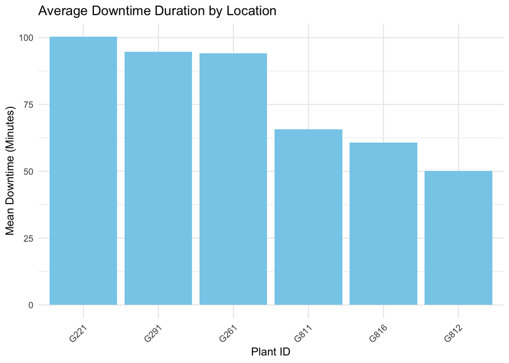

```r
library(ggplot2)

# Plot average downtime by location
ggplot(avg_downtime_by_location, aes(x = reorder(PLANT_ID, -mean_downtime), y = mean_downtime)) +
  geom_bar(stat = "identity", fill = "skyblue") +
  theme_minimal() +
  labs(
    title = "Average Downtime Duration by Location",
    x = "Plant ID",
    y = "Mean Downtime (Minutes)"
  ) +
  theme(axis.text.x = element_text(angle = 45, hjust = 1))
```

This visualization highlights which locations experience the highest average downtime, enabling targeted interventions to reduce delays. G221 with the most.

```r
# Calculate mean and median downtime by maintenance type
downtime_by_maintenance_type <- iwc_data %>%
  group_by(MAINTENANCE_TYPE_DESCRIPTION) %>%
  summarize(
    mean_downtime = mean(ACTUAL_WORK_IN_MINUTES, na.rm = TRUE),
    median_downtime = median(ACTUAL_WORK_IN_MINUTES, na.rm = TRUE),
    count = n()
  ) %>%
  arrange(desc(mean_downtime))

# View the result
print(downtime_by_maintenance_type)
```

```
## # A tibble: 6 × 4
##   MAINTENANCE_TYPE_DESCRIPTION   mean_downtime median_downtime   count
##   <chr>                                  <dbl>           <dbl>   <int>
## 1 "Breakdown Maintenance Order"          207.             205.       5
## 2 "Corrective Maintenance Order"         135.              60   134074
## 3 "Administrative Order"                 122.              60     6161
## 4 ""                                      88.4             48  1135469
## 5 "Capital Order"                         55.0             30       22
## 6 "Preventive Maintenance Order"          48.6             30   151533
```

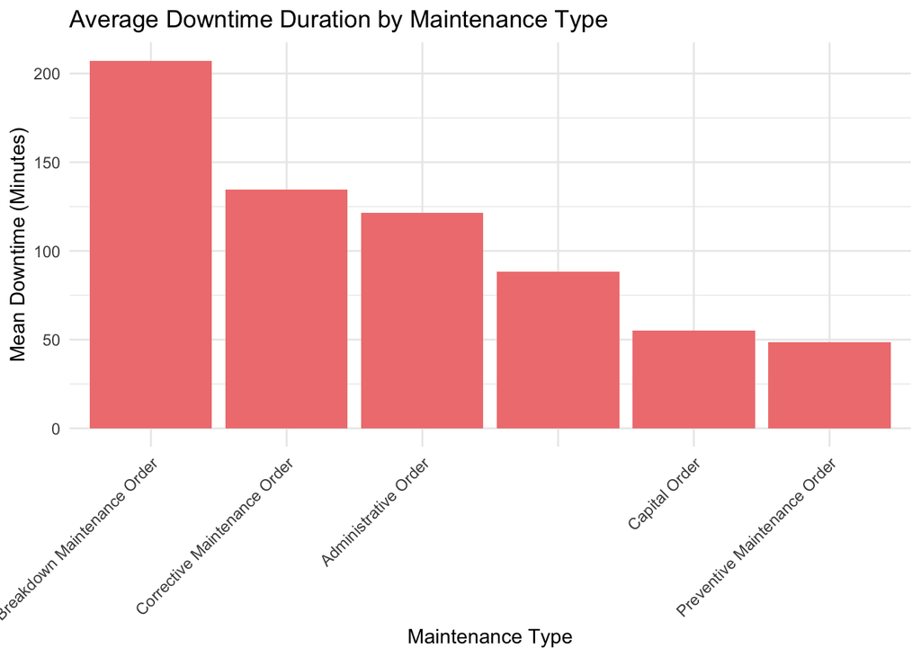

```r
# Plot downtime by maintenance type
ggplot(downtime_by_maintenance_type, aes(x = reorder(MAINTENANCE_TYPE_DESCRIPTION, -mean_downtime), y = mean_downtime)) +
  geom_bar(stat = "identity", fill = "lightcoral") +
  theme_minimal() +
  labs(
    title = "Average Downtime Duration by Maintenance Type",
    x = "Maintenance Type",
    y = "Mean Downtime (Minutes)"
  ) +
  theme(axis.text.x = element_text(angle = 45, hjust = 1))
```

Maintenance types with higher average downtime durations represent key areas for process improvement to enhance operational efficiency. Breakdown Maintenance Order is the highest average downtime duration.